# Mockarooからの項目との質問

このRMarkdownのデジタル書では、実験し、練習し、数質問などを扱うつもりである． データは、便利に項目を作れるMockarooのウェブサイトから取られた．空想的な会社が この書で想像されるかもしれない．

読者様は、要点が欲しければ、「つまり」と言う部分にいらっしゃることが 可能であります．この書の終わりにございます．

# 前付け

## ライブラリーの始動

```r
library(data.table)
# library(moments)
library(ggplot2)
library(RPostgres)
library(rstudioapi)
library(rnaturalearth)
library(sf)
library(patchwork)
```

## SQLへのコネクション設定

```r
con <- dbConnect(RPostgres::Postgres(),
                 host = 'localhost',
                 dbname = 'experimentation_01',
                 user = 'postgres',
                 password = rstudioapi::askForPassword('Password: ')
)
```

## 構造

### テーブル

テーブルは、一つの簡単なテーブルであり、`persons`の名前がある． 次で構造が見える：

```
     Column     |         Type          | Collation | Nullable |               Default
----------------+-----------------------+-----------+----------+-------------------------------------
 id             | smallint              |           | not null | nextval('persons_id_seq'::regclass)
 last_name      | character varying(50) |           |          |
 first_name     | character varying(50) |           |          |
 gender         | character varying(1)  |           |          |
 dob            | date                  |           |          |
 country        | character varying(50) |           |          |
 phone          | character varying(20) |           |          |
 email          | character varying(50) |           |          |
 monthly_income | numeric(6,2)          |           |          |
Indexes:
    "persons_pkey" PRIMARY KEY, btree (id)
```

このテーブルは、MockarooからのSQLスクリプトでのテーブルであり、スクリプトで 創造した後で、数所を少々変えたりした．例えば、プライマリなキーを足し、`phone`の 文字列の長さを短くし、`gender`の文字列の長さも短くし、`id`の列のデータ型 を`smallint`に変化した．

### idの列

スクリプトの後で作った`persons_id_seq`は、僕が`smallserial`のデータ型にしたが、 PostgreSQLが`nextval`（smallserialの次の数値）の具合を変化しなくてはいけなかった． すなわち、1の数値は、存在したままであった．こうした事は、続いたままであれば、 新しい項目を`insert`の関数で入れれば、エラーが起こる．であるから、 この場合は`nextval`は手動の活動することで1から1001に変えなければいけない． すなわち、

```sql
-- nextvalの調べ
select nextval('persons_id_seq'::regclass);

-- 結果
nextval
---------
       1
(1 row)

-- 変えるアクション
alter sequence persons_id_seq restart with 1001;
-- 結果
ALTER SEQUENCE -- いい
```

## 通貨

この書で使われている通貨は、空想的であり「M」である．

# 質問

## ｎ

```r
dbGetQuery(con, '
    select count(*) from persons;
')
```

| count |
| --- |
| 1000 |

ｎは、1000であり、1000人の観測がある．

## 性別の回数

### 男性と女性の回数

```r
count_mf <- dbGetQuery(con, '
    select gender, count(*) as frequency
    from persons
    group by gender
    order by frequency desc;
')
count_mf
```

| gender | frequency |
| --- | --- |
| M | 504 |
| F | 496 |

### あらゆる国の方の回数

```r
peoplecount_bycountry <- dbGetQuery(con, '
    select country, count(*)
    from persons
    group by country
    order by count(*) desc;
')
```

このテーブルの国々の国民の回数は、中国と、インドネシア、とロシアは最も 高い回数である．

```r
peoplecount_bycountry
```

| country | count |
| --- | --- |
| China | 169 |
| Indonesia | 109 |
| Russia | 67 |
| Philippines | 47 |
| Portugal | 35 |
| Brazil | 35 |
| United States | 29 |
| Poland | 28 |
| Japan | 24 |
| Peru | 20 |

[output cut: 107 more lines]

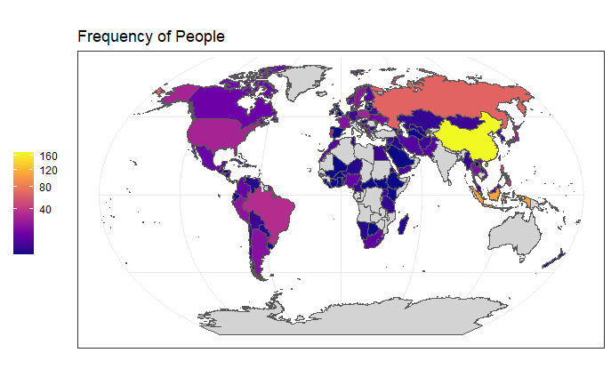

```r
# CSVファイルの始動
peoplecount_bycountry_ <- fread('peoplecount_bycountry.csv')

# 地球図の創造と保存
w_map <- ne_countries(scale='medium', returnclass='sf')

# 地球図とデータの組み合わせ
w_map_peoplecount <- merge(w_map, peoplecount_bycountry_, by.x='name', by.y='country', all=T)

# 可視化
w_map_peoplecount_p <- ggplot(w_map_peoplecount) +
    theme_bw() +
    geom_sf(aes(fill=people_count)) +
    scale_fill_viridis_c(option='plasma', trans='sqrt', na.value='lightgrey') +
    ggtitle('Frequency of People') +
    theme(legend.title=element_blank(), legend.position='left')
# 標準図法よりいい投影方法
w_map_peoplecount_p +
    coord_sf(crs='+proj=kav7')
```

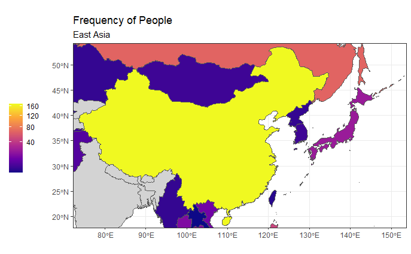

```r
# 東亜
w_map_peoplecount_p_eastasia <- w_map_peoplecount_p +
    coord_sf(xlim=c(76, 150), ylim=c(19.5, 52.5)) +
    labs(subtitle='East Asia')

w_map_peoplecount_p_eastasia
```

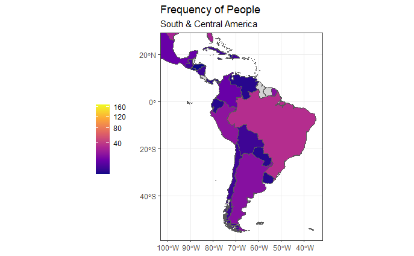

```r
# 南米
w_map_peoplecount_p_samerica <- w_map_peoplecount_p +
    coord_sf(xlim=c(-100, -35), ylim=c(-55, 25)) +
    labs(subtitle='South & Central America')

w_map_peoplecount_p_samerica
```

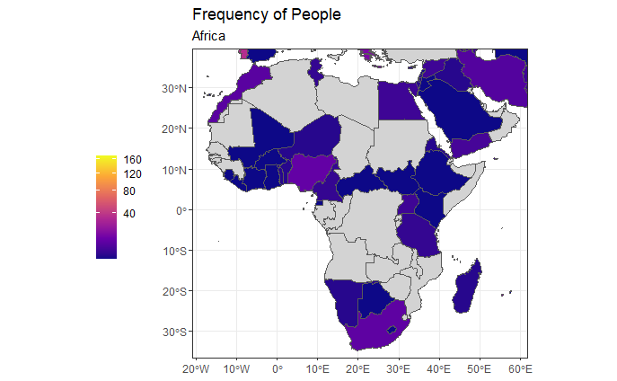

```r
# アフリカ
w_map_peoplecount_africa_p <- w_map_peoplecount_p +
    coord_sf(xlim=c(-17, 58), ylim=c(-33, 36)) +
    labs(subtitle='Africa')

w_map_peoplecount_africa_p
```

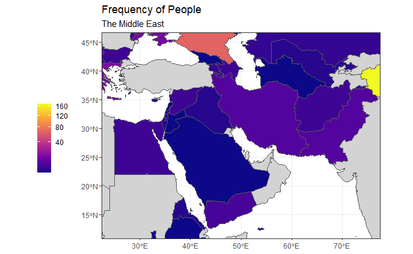

```r
# 中東
w_map_peoplecount_p_middleeast <- w_map_peoplecount_p +
    coord_sf(xlim=c(25, 75), ylim=c(12.5, 45)) +
    labs(subtitle='The Middle East')

w_map_peoplecount_p_middleeast
```

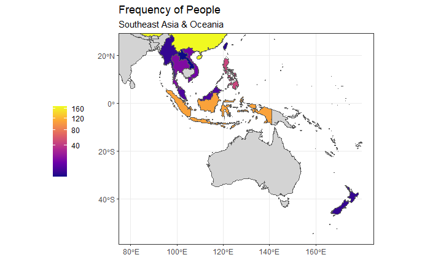

```r
# 東南亜とオセアニア
w_map_peoplecount_p_seastasia_oceania <- w_map_peoplecount_p +
    coord_sf(xlim=c(80, 180), ylim=c(-55, 25)) +
    labs(subtitle='Southeast Asia & Oceania')

w_map_peoplecount_p_seastasia_oceania
```

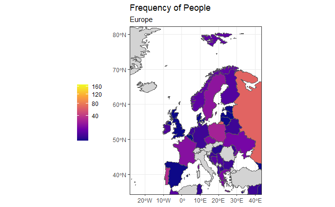

```r
# ヨーロッパ
w_map_peoplecount_p_europe <- w_map_peoplecount_p +
    coord_sf(xlim=c(-25, 40), ylim=c(36.5, 80)) +
    labs(subtitle='Europe')

w_map_peoplecount_p_europe
```

## 毎月の所得

毎月の所得については、分布がある．

```r
# 所得の分布を可視化する
incomes <- dbGetQuery(con, '
    select
        gender,
        extract(year from dob) as birthyear,
        monthly_income
    from persons;
')
incomes <- as.data.table(incomes)
head(incomes)  # 表の小さい部分が見える
```

| gender | birthyear | monthly_income |
| --- | --- | --- |
| F | 1976 | 3984.22 |
| F | 1971 | 4712.54 |
| F | 1975 | 2016.40 |
| F | 1973 | 2272.53 |
| F | 1999 | 2345.10 |
| F | 1974 | 4107.08 |

### いくつかの速い点

```r
summary(incomes[, 3])
```

```
 monthly_income
 Min.   :1404
 1st Qu.:2301
 Median :3186
 Mean   :3186
 3rd Qu.:4063
 Max.   :5000
```

相加平均と中位数は、本当に同じであるか．

```r
mean(incomes$monthly_income)
```

```
[1] 3185.8
```

```r
median(incomes$monthly_income)
```

```
[1] 3186.5
```

範囲は、

```r
range(incomes[, 3])
```

```
[1] 1404.40 4999.97
```

3595.57である．

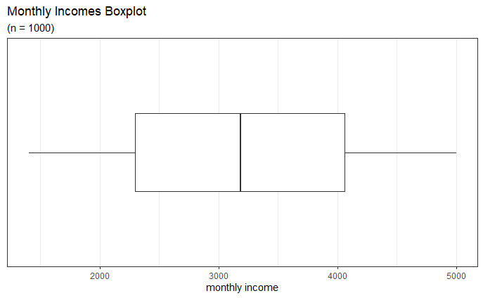

```r
# 箱ひげ図
# might make this visually nicer
monthly_incomes_boxplot <- ggplot(data=incomes, aes(y=monthly_income)) +
    geom_boxplot() +
    theme_bw() +
    labs(title='Monthly Incomes Boxplot', subtitle='(n = 1000)') +
    ylab('monthly income') +
    coord_flip(xlim=c(-1, 1)) +
    theme(axis.text.y=element_blank()) +
    theme(axis.ticks.y=element_blank()) +
    theme(panel.grid.major.y=element_blank()) +
    theme(panel.grid.minor.y=element_blank())

monthly_incomes_boxplot
```

### 正規なフォームと可視化

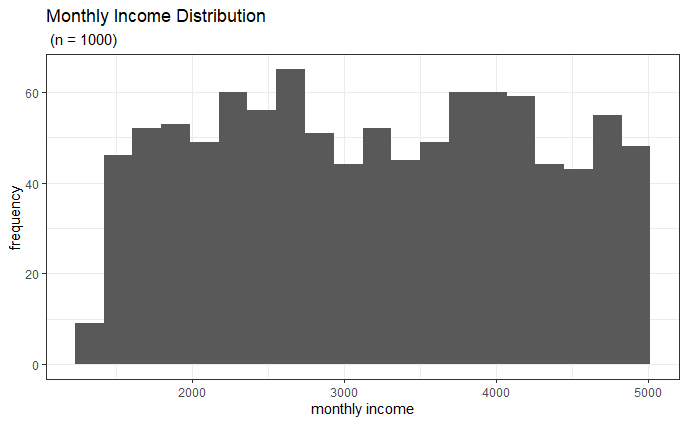

```r
# check whether income distribution is normal
# 所得の分布が正規分布であるか調べられる
# maybe make visually nicer
    # also be consistent and use M for currency, so also put it in preliminaries
monthly_income_dist <- ggplot(data=incomes, aes(monthly_income)) +
    geom_histogram(bins=20) +
    labs(title='Monthly Income Distribution', subtitle=' (n = 1000)') +
    xlab('monthly income') +
    ylab('frequency') +
    theme_bw()

monthly_income_dist
```

その分布の可視化を見ることでは、正規分布ではないことが直接的に知られる． Shapiro-Wilksの計算は、この場合、きっと必要ではないであろうものの、 発揮のために果たされる．

```r
shapiro.test(incomes$monthly_income)
```

```
    Shapiro-Wilk normality test

data:  incomes$monthly_income
W = 0.95561, p-value < 2.2e-16
```

その結果は見えれば、もちろん正規分布ではないと結論するのはいい事である．その上、QQ図も（統計向けの他のソフトウェアで） 可能である：

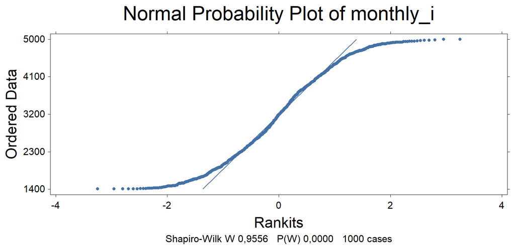

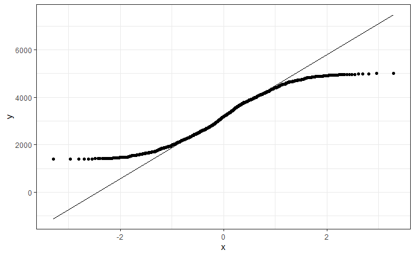

```r
# ggplot2でのQQ図
monthly_income_qqplot <- ggplot(data=incomes, aes(sample=monthly_income)) +
    stat_qq() +
    stat_qq_line() +
    theme_bw()

monthly_income_qqplot
```

その余分な可視化を見ることでは、明らかに分布が正規分布ではない．

### 男性と女性の間にある所得の違い

```r
# ここでグルーピングのアクションである
incomes[, .(mean_income = mean(monthly_income),
            median_income = median(monthly_income)),
            by=gender]
```

| gender | mean_income | median_income |
| --- | --- | --- |
| F | 3190.25 | 3207.225 |
| M | 3181.42 | 3167.675 |

### 年齢と収入について

この場合は、データが一応むやみにMockarooをとうして取られたので、年齢と所得は 重い相関がないであろう：

```r
cor(incomes$birthyear, incomes$monthly_income)
```

```
[1] -0.02577907
```

本当である．

# 最高な金を得る人がいる国

## トップの１０画の平均的な所得

平均的に最高な金を得る人がいる国は、トップの１０国が調べられるように．

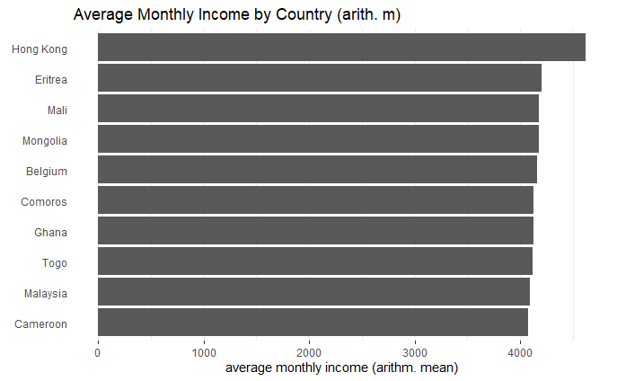

```r
# the first 10 countries
# improve visualization
avg_monthlyincome_bycountry_10 <-  dbGetQuery(con, '
    select
        country,
        round(avg(monthly_income)) as avg_monthly_income
    from persons
    group by country
    order by avg_monthly_income desc
    limit 10;
')
avg_monthlyincome_bycountry_10_p <- ggplot(avg_monthlyincome_bycountry_10,
       aes(avg_monthly_income, reorder(country, avg_monthly_income))) +
    geom_col() +
    theme_bw() +
    labs(title='Average Monthly Income by Country (arith. m)') +
    xlab('average monthly income (arithm. mean)') +
    ylab(element_blank()) +
    theme(axis.ticks.y=element_blank()) +
    theme(panel.grid.major.y=element_blank()) +
    theme(panel.grid.minor.y=element_blank())

avg_monthlyincome_bycountry_10_p + theme(rect=element_blank())
```

## 各国の平均的な所得

```r
avg_monthlyincome_bycountry <- dbGetQuery(con, '
    select
        country,
        round(avg(monthly_income)) as avg_monthly_income
    from persons
    group by country
    order by avg_monthly_income desc
')

avg_monthlyincome_bycountry
```

| country | avg_monthly_income |
| --- | --- |
| Hong Kong | 4622 |
| Eritrea | 4205 |
| Mali | 4180 |
| Mongolia | 4178 |
| Belgium | 4165 |
| Comoros | 4126 |
| Ghana | 4125 |
| Togo | 4116 |
| Malaysia | 4095 |
| Cameroon | 4076 |

[output cut: 107 more lines]

### 可視化

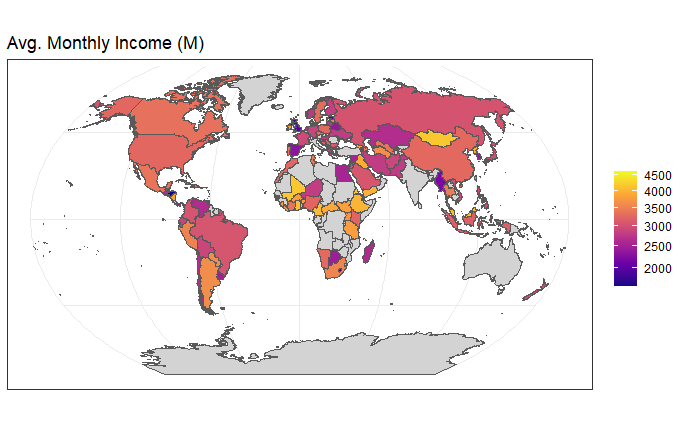

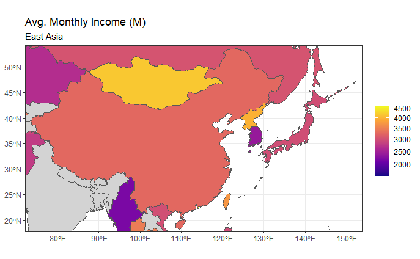

```r
w_map_avg_monthlyincome_bycountry_p_eastasia <- avg_monthlyincome_bycountry_p +
    coord_sf(xlim=c(76, 150), ylim=c(19.5, 52.5)) +
    labs(subtitle='East Asia')
w_map_avg_monthlyincome_bycountry_p_eastasia
```

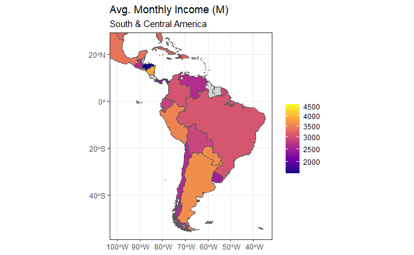

```r
w_map_avg_monthlyincome_bycountry_p_samerica <- avg_monthlyincome_bycountry_p +
    coord_sf(xlim=c(-100, -35), ylim=c(-55, 25)) +
    labs(subtitle='South & Central America')
w_map_avg_monthlyincome_bycountry_p_samerica
```

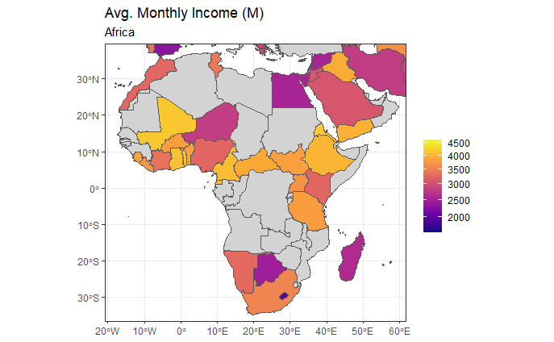

```r
w_map_avg_monthlyincome_bycountry_p_africa <- avg_monthlyincome_bycountry_p +
    coord_sf(xlim=c(-17, 58), ylim=c(-33, 36)) +
    labs(subtitle='Africa')
w_map_avg_monthlyincome_bycountry_p_africa
```

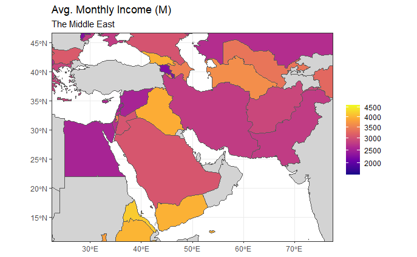

```r
w_map_avg_monthlyincome_bycountry_p_middleeast <- avg_monthlyincome_bycountry_p +
    coord_sf(xlim=c(25, 75), ylim=c(12.5, 45)) +
    labs(subtitle='The Middle East')
w_map_avg_monthlyincome_bycountry_p_middleeast
```

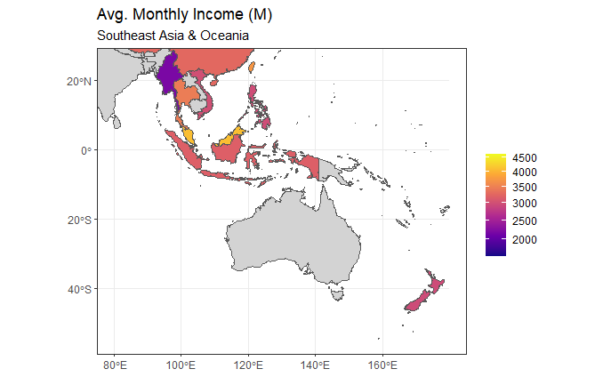

```r
w_map_avg_monthlyincome_bycountry_p_seastasia_oceania <- avg_monthlyincome_bycountry_p +
    coord_sf(xlim=c(80, 180), ylim=c(-55, 25)) +
    labs(subtitle='Southeast Asia & Oceania')
w_map_avg_monthlyincome_bycountry_p_seastasia_oceania
```

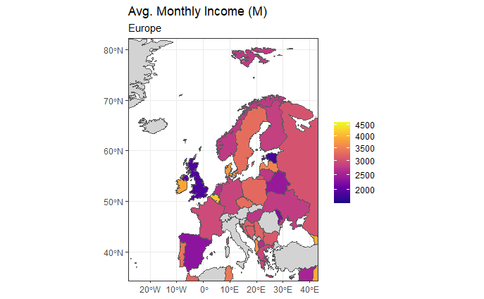

```r
w_map_avg_monthlyincome_bycountry_p_europe <- avg_monthlyincome_bycountry_p +
    coord_sf(xlim=c(-25, 40), ylim=c(36.5, 80)) +
    labs(subtitle='Europe')
w_map_avg_monthlyincome_bycountry_p_europe
```

# つまり

この書では、Mockarooで空想的な項目を作り、SQLのスクリプトで項目を入れた． テーブルの構造の為に必要な変わりを果たし、自動化のある事を処理した．記述統計学を 果たし、正規分布を探し、相関を探した．可視化も果たした．

## 数要点

```
ｎ　　　：　1000
男性の数：　504
女性の数：　496

人の最高な回数：　中国

  　　収入について（Ｍの通貨で）
収入の相加平均：　3185.80

２５％までの人：　~1404 -- 2301
次の２５％　　：　2301 -- 3186
次の２５％　　：　3186 -- 4063
次の２５％　　：　4063 -- 5000

収入の範囲　　：　1404.40 -- 4999.97　　（3595.57）

正規分布は、ない．

女性の収入の中位数：　3207
男性の収入の中位数：　3167

年齢と収入は、相関がない．
最高な収入：　香港
```

## この書の可視化

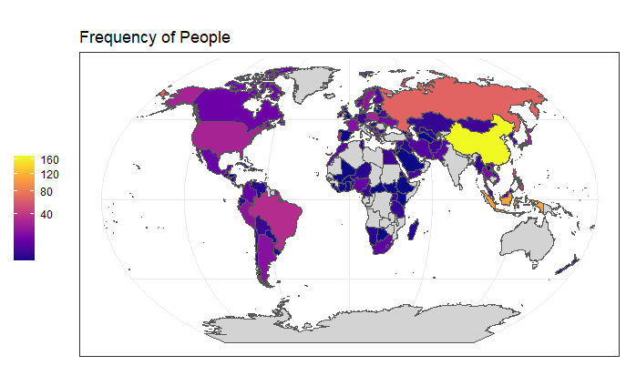

```r
w_map_peoplecount_p + coord_sf(crs='+proj=kav7')
```

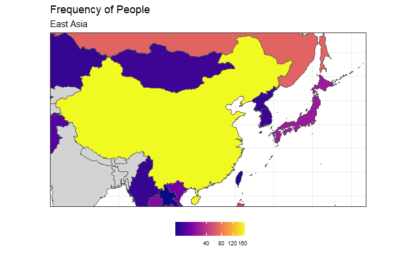

```r
w_map_peoplecount_p_eastasia +
    theme(axis.ticks=element_blank(), axis.text=element_blank()) +
    theme(legend.position='bottom', legend.text=element_text(size=7))
```

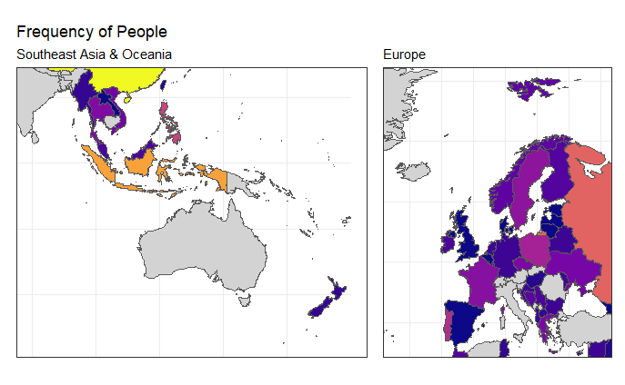

```r
w_map_peoplecount_p_seastasia_oceania +
    theme(legend.position='none', axis.text=element_blank(), axis.ticks=element_blank()) +
    w_map_peoplecount_p_europe +
    theme(legend.position='none') +
    theme(axis.text=element_blank(), axis.ticks=element_blank()) +
    labs(title=element_blank())
```

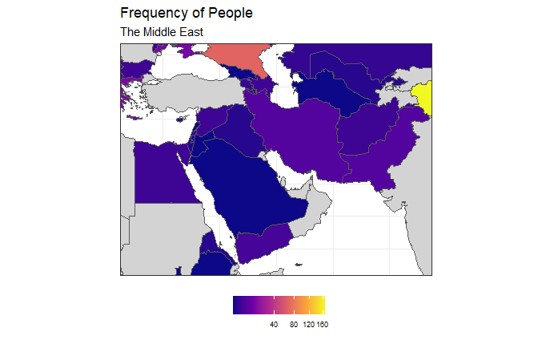

```r
w_map_peoplecount_p_middleeast +
    theme(axis.text=element_blank()) +
    theme(legend.position='bottom', legend.text=element_text(size=7)) +
    theme(axis.ticks=element_blank())
```

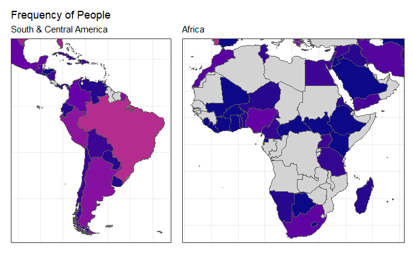

```r
w_map_peoplecount_p_samerica +
    theme(legend.position='none', axis.text=element_blank()) +
    theme(axis.ticks=element_blank()) +
    w_map_peoplecount_africa_p +
    theme(legend.position='none', axis.text=element_blank(), axis.ticks=element_blank()) +
    labs(title=element_blank())
```

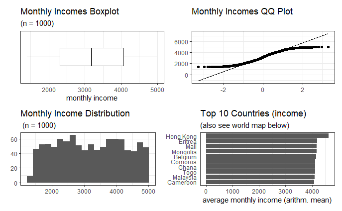

```r
# 可視化への便利な変数
p_boxplot <- monthly_incomes_boxplot
p_qqplot <- monthly_income_qqplot + labs(title='Monthly Incomes QQ Plot') + xlab(element_blank()) + ylab(element_blank())
p_top10 <- avg_monthlyincome_bycountry_10_p+ggtitle('Top 10 Countries (income)')
p_dist <- monthly_income_dist+ylab(element_blank())+xlab(element_blank())

# 可視化
(p_boxplot|p_qqplot) /
(p_dist| (p_top10+labs(subtitle='(also see world map below)')))
```

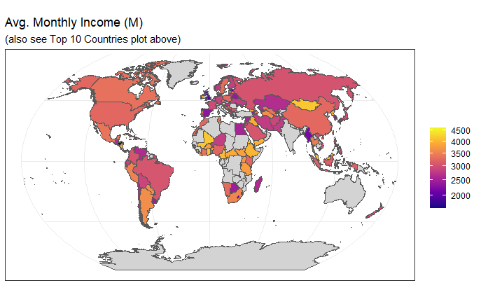

```r
avg_monthlyincome_bycountry_p + coord_sf(crs='+proj=kav7') +
    labs(subtitle='(also see Top 10 Countries plot above)')
```

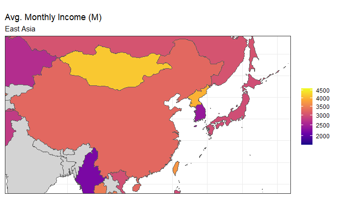

```r
# 視化
p_avgincome_eastasia
```

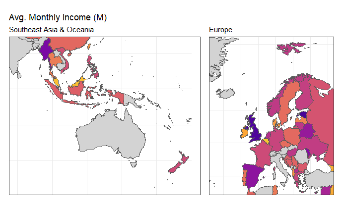

```r
p_avgincome_seastasia_oceania
```

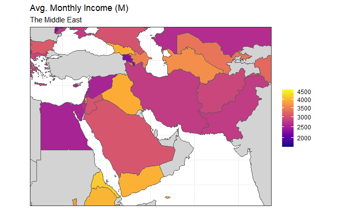

```r
p_avgincome_middleeast
```

[figure not shown]

```r
p_avgincome_samerica_camerica_africa
```

# 将来か未来

将来か未来は、地図の可視化にインタラクティビティーを注入したい．その道では、 こうした書を見る者は、地図を見る方が快適なのである．